# Group Project: Telemarketing

10/12/2023

## Libraries

```r
library(ggplot2)
library(dplyr)
library(caret)
library(neuralnet)
```

# Preparing Data

## Downloading and Prepping the Data

```r
#Downloading and Prepping the Data
tele <- read.csv("tele.csv", stringsAsFactors = TRUE)
summary(tele)
```

```
##        X              age                 job            marital
##  Min.   :    1   Min.   :17.00   admin.     :10422   divorced: 4612
##  1st Qu.:10298   1st Qu.:32.00   blue-collar: 9254   married :24928
##  Median :20595   Median :38.00   technician : 6743   single  :11568
##  Mean   :20595   Mean   :40.02   services   : 3969   unknown :   80
##  3rd Qu.:30891   3rd Qu.:47.00   management : 2924
##  Max.   :41188   Max.   :98.00   retired    : 1720
##                                  (Other)    : 6156
##                education        default         housing           loan
##  university.degree  :12168   no     :32588   no     :18622   no     :33950
##  high.school        : 9515   unknown: 8597   unknown:  990   unknown:  990
##  basic.9y           : 6045   yes    :    3   yes    :21576   yes    : 6248
##  professional.course: 5243
##  basic.4y           : 4176
##  basic.6y           : 2292
##  (Other)            : 1749
##       contact          month       day_of_week    duration
##  cellular :26144   may    :13769   fri:7827    Min.   :   0.0
##  telephone:15044   jul    : 7174   mon:8514    1st Qu.: 102.0
##                    aug    : 6178   thu:8623    Median : 180.0
##                    jun    : 5318   tue:8090    Mean   : 258.3
##                    nov    : 4101   wed:8134    3rd Qu.: 319.0
##                    apr    : 2632               Max.   :4918.0
##                    (Other): 2016
##     campaign          pdays          previous            poutcome
##  Min.   : 1.000   Min.   :  0.0   Min.   :0.000   failure    : 4252
##  1st Qu.: 1.000   1st Qu.:999.0   1st Qu.:0.000   nonexistent:35563
##  Median : 2.000   Median :999.0   Median :0.000   success    : 1373
##  Mean   : 2.568   Mean   :962.5   Mean   :0.173
##  3rd Qu.: 3.000   3rd Qu.:999.0   3rd Qu.:0.000
##  Max.   :56.000   Max.   :999.0   Max.   :7.000
##
##   emp.var.rate      cons.price.idx  cons.conf.idx     euribor3m
##  Min.   :-3.40000   Min.   :92.20   Min.   :-50.8   Min.   :0.634
##  1st Qu.:-1.80000   1st Qu.:93.08   1st Qu.:-42.7   1st Qu.:1.344
##  Median : 1.10000   Median :93.75   Median :-41.8   Median :4.857
##  Mean   : 0.08189   Mean   :93.58   Mean   :-40.5   Mean   :3.621
##  3rd Qu.: 1.40000   3rd Qu.:93.99   3rd Qu.:-36.4   3rd Qu.:4.961
##  Max.   : 1.40000   Max.   :94.77   Max.   :-26.9   Max.   :5.045
##
##   nr.employed     y
##  Min.   :4964   no :36548
##  1st Qu.:5099   yes: 4640
##  Median :5191
##  Mean   :5167
##  3rd Qu.:5228
##  Max.   :5228
##
```

```r
#We are deleting the "duration" variable because it is an after the fact measurement. We only should be using variables that we know before the call
tele$duration <- NULL

# Deleting the column X
tele$X <- NULL

# Changing pdays to a dummy and deleting pdays
tele$pdaysdummy <- ifelse(tele$pdays == 999, 0, 1)
tele$pdays <- NULL

str(tele)
```

```
## 'data.frame':    41188 obs. of  20 variables:
##  $ age           : int  56 57 37 40 56 45 59 41 24 25 ...
##  $ job           : Factor w/ 12 levels "admin.","blue-collar",..: 4 8 8 1 8 8 1 2 10 8 ...
##  $ marital       : Factor w/ 4 levels "divorced","married",..: 2 2 2 2 2 2 2 2 3 3 ...
##  $ education     : Factor w/ 8 levels "basic.4y","basic.6y",..: 1 4 4 2 4 3 6 8 6 4 ...
##  $ default       : Factor w/ 3 levels "no","unknown",..: 1 2 1 1 1 2 1 2 1 1 ...
##  $ housing       : Factor w/ 3 levels "no","unknown",..: 1 1 3 1 1 1 1 1 3 3 ...
##  $ loan          : Factor w/ 3 levels "no","unknown",..: 1 1 1 1 3 1 1 1 1 1 ...
##  $ contact       : Factor w/ 2 levels "cellular","telephone": 2 2 2 2 2 2 2 2 2 2 ...
##  $ month         : Factor w/ 10 levels "apr","aug","dec",..: 7 7 7 7 7 7 7 7 7 7 ...
##  $ day_of_week   : Factor w/ 5 levels "fri","mon","thu",..: 2 2 2 2 2 2 2 2 2 2 ...
##  $ campaign      : int  1 1 1 1 1 1 1 1 1 1 ...
##  $ previous      : int  0 0 0 0 0 0 0 0 0 0 ...
##  $ poutcome      : Factor w/ 3 levels "failure","nonexistent",..: 2 2 2 2 2 2 2 2 2 2 ...
##  $ emp.var.rate  : num  1.1 1.1 1.1 1.1 1.1 1.1 1.1 1.1 1.1 1.1 ...
##  $ cons.price.idx: num  94 94 94 94 94 ...
##  $ cons.conf.idx : num  -36.4 -36.4 -36.4 -36.4 -36.4 -36.4 -36.4 -36.4 -36.4 -36.4 ...
##  $ euribor3m     : num  4.86 4.86 4.86 4.86 4.86 ...
##  $ nr.employed   : num  5191 5191 5191 5191 5191 ...
##  $ y             : Factor w/ 2 levels "no","yes": 1 1 1 1 1 1 1 1 1 1 ...
##  $ pdaysdummy    : num  0 0 0 0 0 0 0 0 0 0 ...
```

## Getting Data Ready for Analysis

```r
# Using model.matrix to convert all the factors to dummy variables
# We are converting all of the factors into dummy variables as the input into knn has to be numeric

telemm <- as.data.frame(model.matrix(~.-1,tele))
str(telemm)
```

```
## 'data.frame':    41188 obs. of  54 variables:
##  $ age                         : num  56 57 37 40 56 45 59 41 24 25 ...
##  $ jobadmin.                   : num  0 0 0 1 0 0 1 0 0 0 ...
##  $ jobblue-collar              : num  0 0 0 0 0 0 0 1 0 0 ...
##  $ jobentrepreneur             : num  0 0 0 0 0 0 0 0 0 0 ...
##  $ jobhousemaid                : num  1 0 0 0 0 0 0 0 0 0 ...
##  $ jobmanagement               : num  0 0 0 0 0 0 0 0 0 0 ...
##  $ jobretired                  : num  0 0 0 0 0 0 0 0 0 0 ...
##  $ jobself-employed            : num  0 0 0 0 0 0 0 0 0 0 ...
##  $ jobservices                 : num  0 1 1 0 1 1 0 0 0 1 ...
##  $ jobstudent                  : num  0 0 0 0 0 0 0 0 0 0 ...
##  $ jobtechnician               : num  0 0 0 0 0 0 0 0 1 0 ...
##  $ jobunemployed               : num  0 0 0 0 0 0 0 0 0 0 ...
##  $ jobunknown                  : num  0 0 0 0 0 0 0 0 0 0 ...
##  $ maritalmarried              : num  1 1 1 1 1 1 1 1 0 0 ...
```

[output cut: 40 more lines]

```r
#Normalize the data
normalize <- function(x) {
  return ((x - min(x)) / (max(x) - min(x)))
}

# we are going to normalize everything for KNN and ANN
tele_norm <- as.data.frame(lapply(telemm, normalize))
```

## Getting Train and Test Samples

```r
# Selects 10000 random rows for test data
set.seed(12345)
test_set <- sample(1:nrow(tele_norm), 10000)
# Depending on R-version and computer, different rows may be selected.
# If that happens, results are different.

# Create a train set and test set
#First the predictors - all columns except the yyes column
tele_train <- tele_norm[-test_set, -match("yyes",names(tele_norm))]
tele_test <- tele_norm[test_set, -match("yyes",names(tele_norm))]

#Now the response (aka Labels) - only the yyes column
tele_train_labels <- tele_norm[-test_set, "yyes"]
tele_test_labels <- tele_norm[test_set, "yyes"]

#train and test set that includes yyes
tele_train_all = tele_norm[-test_set,]
tele_test_all = tele_norm[test_set,]
```

# Clusters

## Training the model

```r
set.seed(12345)

# Removing the Y column
tele_data <- telemm[ , -53]

# z-Scaling the data
tele_z <- as.data.frame(lapply(tele_data, scale))

tele_clusters <- kmeans(tele_z, 6)

tele_clusters$centers
```

```
##           age   jobadmin. jobblue.collar jobentrepreneur jobhousemaid
## 1  0.02452166 -0.09769261    0.178715525      0.04751443  0.006399343
## 2  0.03217056  0.05302102   -0.100564516     -0.05181553 -0.039452607
## 3 -0.10940517 -0.55630934   -0.525530542     -0.18042418 -0.141673485
## 4  0.03468172  0.13804345    0.155755092      0.01601821  0.086995521
## 5 -0.08402855  0.01441859   -0.002198381     -0.02155698 -0.064604271
## 6  0.08525841  0.01465558   -0.174540564      0.18163838 -0.028658377
##   jobmanagement  jobretired jobself.employed  jobservices  jobstudent
## 1   -0.03161838 -0.06818077      0.015151391  0.040680898 -0.09024773
## 2   -0.01478531  0.17382817     -0.041097124 -0.009413875  0.24404662
## 3   -0.27544290 -0.17320217     -0.168154529 -0.301590681 -0.14027906
## 4    0.02412076 -0.02706690      0.029883242  0.082855510 -0.08892316
## 5   -0.01402293  0.09831327      0.001143096 -0.008046537  0.18684623
## 6    0.27349738 -0.07232347      0.083907492 -0.049093244 -0.11057410
##   jobtechnician jobunemployed   jobunknown maritalmarried maritalsingle
```

[output cut: 62 more lines]

## Visualizations to support cluster descriptions

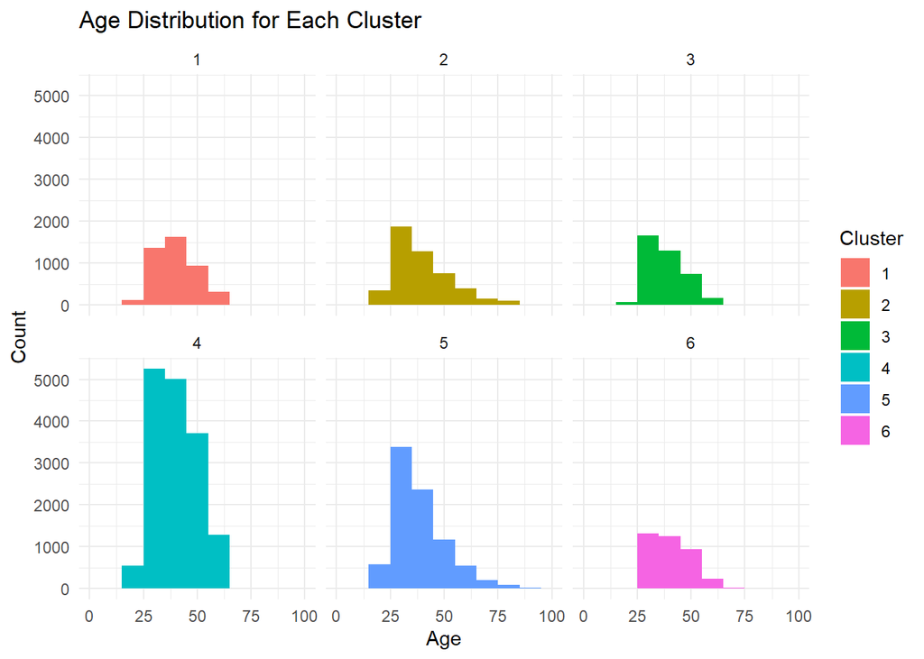

```r
# Assuming you have these libraries loaded
library(ggplot2)

# Adding cluster assignments to your original data
tele_data$cluster <- tele_clusters$cluster

# Creating the histogram using ggplot2
ggplot(tele_data, aes(x=age, fill=factor(cluster))) +
  geom_histogram(binwidth = 10, position="identity", alpha=1) +
  xlim(0, 100) +
  labs(title = "Age Distribution for Each Cluster",
       x = "Age",
       y = "Count",
       fill = "Cluster") +
       facet_wrap(~ cluster, ncol = 3) + # Separate histograms for each cluster

  theme_minimal()
```

The line graphs below shows the average succesrate for all ages. Here it is evident that the young and older people tend to say ‘Yes’ more often. However, the significant fluctuations are caused by the fewer but succesful calls to the ages.

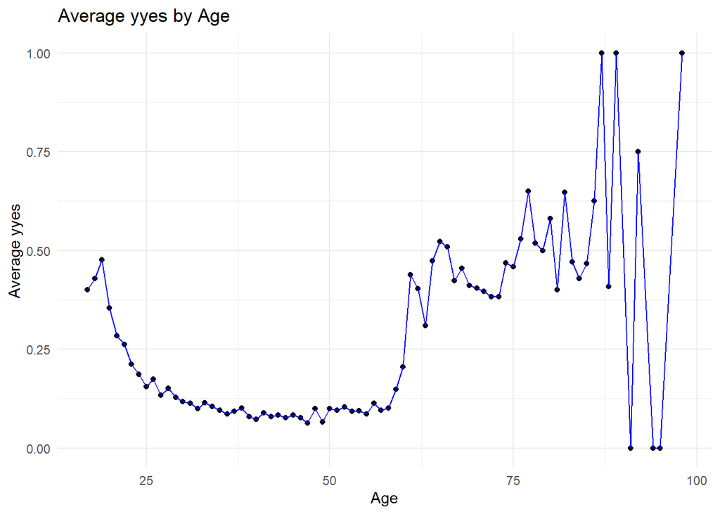

```r
library(dplyr)

avg_yyes_by_age <- telemm %>%
  group_by(age) %>%
  summarise(average_yyes = mean(yyes, na.rm = TRUE))

library(ggplot2)

ggplot(avg_yyes_by_age, aes(x = age, y = average_yyes)) +
  geom_point() +
  geom_line(group = 1, color = "blue") +
  labs(title = "Average yyes by Age", x = "Age", y = "Average yyes") +
  theme_minimal()
```

```r
telemm$cluster <- tele_clusters$cluster

# Step 1: Store the results of the aggregate function
agg_data <- aggregate( data = telemm, yyes ~ cluster, mean)

# Step 2: Create a new column for the size
agg_data$cluster_size <- NA  # Initialize with NA

# Step 3: Assign the sizes to the appropriate clusters
for(i in 1:nrow(agg_data)) {
  agg_data$cluster_size[i] <- tele_clusters$size[agg_data$cluster[i]]
}

# Step 4: Calculate profit for all clusters

# OLD PROFIT FUNCTION
# agg_data$profit <- ((11 * agg_data$cluster_size) * agg_data$yyes) - (2 * agg_data$cluster_size)

calls_made = agg_data$cluster_size
succesful_calls = agg_data$cluster_size*agg_data$yyes
success_rate <- agg_data$yyes


old_success_rate <- mean(tele_norm$y)


calls_per_agent <- ((success_rate - old_success_rate) * 100 * 100) + 1000


costs <- calls_made * (1000 / calls_per_agent) + (calls_made * 1)
revenue <- succesful_calls * 11

agg_data$profit2 <- round(revenue - costs, 2)

# View the result
agg_data
```

```
##   cluster       yyes cluster_size   profit2
## 1       1 0.04298125         4374 -16728.75
## 2       2 0.29943159         4926   9581.29
## 3       3 0.05029210         3937 -12219.19
## 4       4 0.04919901        15793 -50461.40
## 5       5 0.20706107         8384   6399.40
## 6       6 0.07048225         3774  -7374.24
```

## Description of profitable clusters

The two most profitable clusters are 2 and 5, predominantly comprising students and retirees. Given the product in focus - term deposits — it’s understandable why these groups are interested. With their limited income, the safety and short-term nature of term deposits appeal to them, making it an attractive option for both securing and growing their savings.

Cluster 2 primarily consists of individuals who’ve shown a positive response in past campaigns, as evidenced by high values in ‘previous’ and ‘poutcomesuccess’. In contrast, Cluster 5 seems to be made up of those the call center hasn’t contacted before, given its high ‘poutcomenonexistent’ value and negative scores in the other two metrics.

Cluster 2: Returning Positive Buyers Cluster 5: Untouched Potential

# Majority Vote Algorithms

## Functions

```r
#fp = false positives (customers we called but did not buy a term deposit).
#tp = true positives (customers we called and they did buy a term deposit).
#old_rate = old call success rate, based on test data from confusion matrix, usually around 0.11.
calcu = function(fp,tp, old_rate) {
  #revenue
  rev = tp * 11

  #cost
  total_calls = tp + fp
  new_rate = tp / total_calls
  avg_employee_calls = ((new_rate - old_rate) * 100 * 100) + 1000
  num_employees = ceiling(total_calls / avg_employee_calls)
  train_cost = num_employees * 1000
  cost = (total_calls * 1) + train_cost
  return(rev - cost)
}

#Finds best value to split data
find_max = function(pred){
  #Sequence of values for weighing predictions
  vals = seq(0.005,0.5,by=0.005)
  max = 0
  max_x = 0.005
  for (x in vals){
  preds = ifelse(pred > x, 1,0)
  cm = table(as.factor(preds), as.factor(tele_test_labels))
  fp = cm[2,1]
  tp = cm[2,2]
  old_rate = (tp + cm[1,2]) / (fp + cm[1,1] + tp + cm[1,2])
  hold = calcu(fp,tp, old_rate)
    if(hold > max){
      max = hold
      max_x = x
    }
  }
  return(c(max_x,max))
}
```

## logistical Regression

```r
#set.seed(12345)
#(educationilliterate + day_of_weektue + monthjul + jobadmin. + educationuniversity.degree + jobtechnician + day_of_weekthu + day_of_weekmon + monthdec + jobstudent + monthnov + day_of_weekwed + monthoct + monthsep + jobretired + campaign + I(cons.price.idx**2) + monthmay + defaultunknown + poutcomesuccess + pdaysdummy + monthaug + monthjun + nr.employed + cons.conf.idx + poutcomenonexistent + contacttelephone + cons.price.idx + emp.var.rate + monthmar)
library(caret)
logmod = glm(yyes ~  I(emp.var.rate**2) + (emp.var.rate * .) + . + (defaultunknown * contacttelephone) + (campaign * contacttelephone) + (cons.price.idx * .) + I(cons.price.idx**2), data=tele_train_all, family = 'binomial')
#summary(logmod)
#stepfin = step(logmod, direction = "backward")

logpred = predict(logmod, tele_test_all)
#logpred

maxs = find_max(logpred)
#maxs
logpreds = ifelse(logpred > maxs[1], 1,0)
cm = table(as.factor(logpreds), as.factor(tele_test_labels))
fp = cm[2,1]
tp = cm[2,2]
old_rate = (tp + cm[1,2]) / (fp + cm[1,1] + tp + cm[1,2])
profit = calcu(fp,tp, old_rate)
profit
```

```
## [1] 1547
```

## K-Nearest Neighbors

```r
library(caret)
set.seed(12345)

#may need to change k still
knnmod = knnreg(tele_train_labels ~ ., data=tele_train, k=30)
knnpred = predict(knnmod, tele_test)
#best appears to be k=30 at 0.125
maxs = find_max(knnpred)
maxs
```

```
## [1]    0.125 4008.000
```

```r
knnpreds = ifelse(knnpred > maxs[1] ,1,0)
cm = table(as.factor(knnpreds), as.factor(tele_test_labels))
#cm = confusionMatrix(as.factor(knnpreds),as.factor(tele_test_labels), positive = "1")
cm
```

```
##
##        0    1
##   0 7148  424
##   1 1752  676
```

```r
fp = cm[2,1]
tp = cm[2,2]
old_rate = (tp + cm[1,2]) / (fp + cm[1,1] + tp + cm[1,2])
knnprof = calcu(fp,tp, old_rate)
knnprof
```

```
## [1] 4008
```

## ANN

```r
# simple ANN with only a single hidden neuron
teleANN_model <- neuralnet(formula = yyes ~ ., data = tele_train_all)


# visualize the network topology
plot(teleANN_model)

## Step 4: Evaluating model performance ----
# obtain model results
model_results <- compute(teleANN_model, tele_test_all[1:54])
# obtain predicted strength values
ann_predicted_yes <- model_results$net.result
annpreds = ifelse(ann_predicted_yes > 0.125 ,1,0)
cm = table(as.factor(annpreds), as.factor(tele_test_labels))
cm
```

```
##
##        0    1
##   0 7618  416
##   1 1282  684
```

```r
fp = cm[2,1]
tp = cm[2,2]
old_rate = (tp + cm[1,2]) / (fp + cm[1,1] + tp + cm[1,2])
annprof = calcu(fp,tp, old_rate)
annprof
```

```
## [1] 4558
```

## Majority Vote

```r
#final predictions
final_pred = ifelse(logpreds + knnpreds + annpreds >= 2, 1,0)
cm = table(as.factor(final_pred), as.factor(tele_test_labels))
cm
```

```
##
##        0    1
##   0 7905  467
##   1  995  633
```

```r
fp = cm[2,1]
tp = cm[2,2]
old_rate = (tp + cm[1,2]) / (fp + cm[1,1] + tp + cm[1,2])
final_profit = calcu(fp,tp, old_rate)
final_profit
```

```
## [1] 4335
```

By combining the three predictions from logistical regression, K-nearest neighbors, and ANN, we can find the majority classification, and find the final expected profit as $4335.